# Trabalho Regressão Múltipla e Polinomial

Ana Luiza Garcia e Roubean Jhandson Gomes

23/10/2019

**Parte 1**

Leitura de Dados

```r
library(readxl)
Dados_exercicio_Regressao_Multipla_e_polinomial <- read_excel("C:/Users/analu/Downloads/Dados exercicio Regressao Multipla e polinomial.xls",
                                                               sheet = "Dados Carros")
View(Dados_exercicio_Regressao_Multipla_e_polinomial)
library(tidyverse)
library(GGally)
```

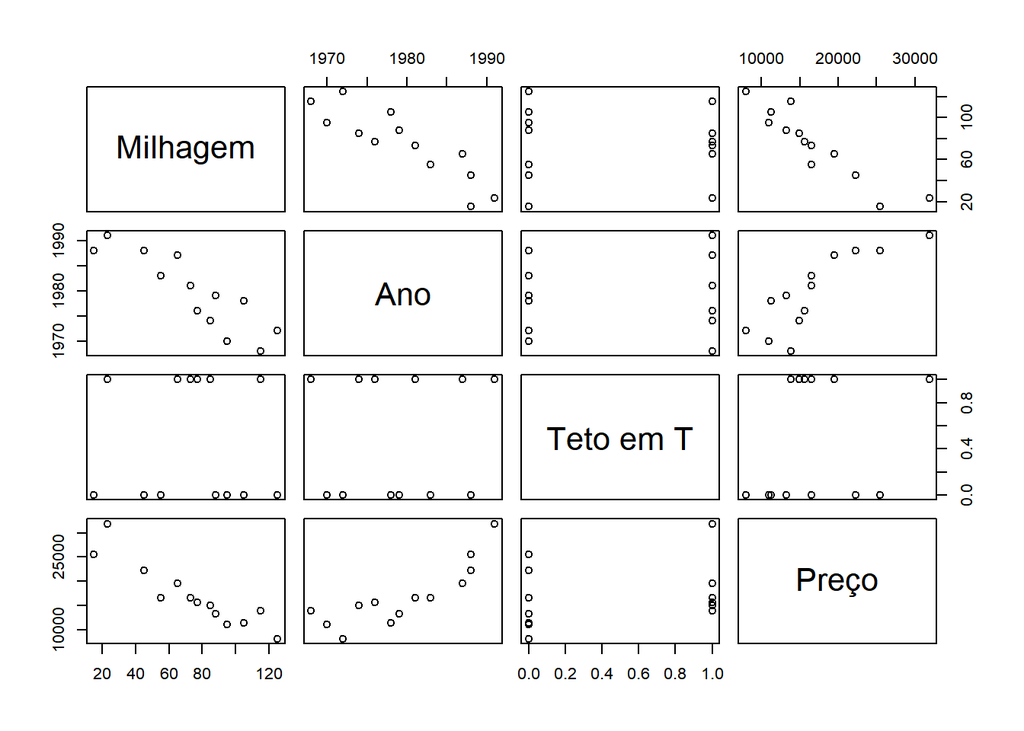

```r
DadosRegressao <- Dados_exercicio_Regressao_Multipla_e_polinomial
view(DadosRegressao)
pairs(DadosRegressao)
```

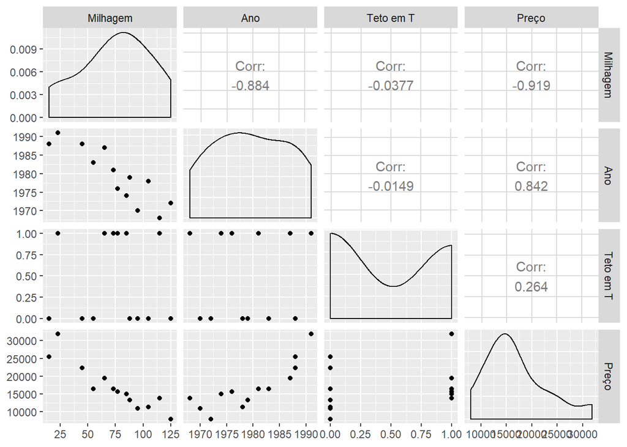

```r
ggpairs(DadosRegressao)
```

Indica que a milhagem tem maior correlação em magnitude, que nos mostra ser a melhor variavel para um modelo simples de apenas uma variavel.

```r
regresx1 <- lm(DadosRegressao$Preço ~ DadosRegressao$Milhagem)
summary(regresx1)
```

```
##
## Call:
## lm(formula = DadosRegressao$Preço ~ DadosRegressao$Milhagem)
##
## Residuals:
##     Min      1Q  Median      3Q     Max
## -3897.8 -1235.2  -139.3   144.1  5768.8
##
## Coefficients:
##                         Estimate Std. Error t value Pr(>|t|)
## (Intercept)             30252.15    1876.75  16.119 5.33e-09 ***
## DadosRegressao$Milhagem  -179.17      23.19  -7.727 9.08e-06 ***
## ---
## Signif. codes:  0 '***' 0.001 '**' 0.01 '*' 0.05 '.' 0.1 ' ' 1
##
## Residual standard error: 2682 on 11 degrees of freedom
## Multiple R-squared:  0.8444, Adjusted R-squared:  0.8303
## F-statistic:  59.7 on 1 and 11 DF,  p-value: 9.076e-06
```

```r
regresx2 <- lm(DadosRegressao$Preço ~ DadosRegressao$Ano)
summary(regresx2)
```

```
##
## Call:
## lm(formula = DadosRegressao$Preço ~ DadosRegressao$Ano)
##
## Residuals:
##     Min      1Q  Median      3Q     Max
## -4454.3 -2919.6  -784.9  2128.0  6615.9
##
## Coefficients:
##                      Estimate Std. Error t value Pr(>|t|)
## (Intercept)        -1434246.2   280151.2   -5.12 0.000334 ***
## DadosRegressao$Ano      733.1      141.5    5.18 0.000304 ***
## ---
## Signif. codes:  0 '***' 0.001 '**' 0.01 '*' 0.05 '.' 0.1 ' ' 1
##
## Residual standard error: 3666 on 11 degrees of freedom
## Multiple R-squared:  0.7092, Adjusted R-squared:  0.6828
## F-statistic: 26.83 on 1 and 11 DF,  p-value: 0.0003037
```

```r
regresx3 <- lm(DadosRegressao$Preço~ DadosRegressao$`Teto em T`)
summary(regresx3)
```

```
##
## Call:
## lm(formula = DadosRegressao$Preço ~ DadosRegressao$`Teto em T`)
##
## Residuals:
##    Min     1Q Median     3Q    Max
##  -7407  -4107  -2225   1093  13175
##
## Coefficients:
##                            Estimate Std. Error t value Pr(>|t|)
## (Intercept)                   15407       2478   6.217 6.56e-05 ***
## DadosRegressao$`Teto em T`     3318       3648   0.910    0.383
## ---
## Signif. codes:  0 '***' 0.001 '**' 0.01 '*' 0.05 '.' 0.1 ' ' 1
##
## Residual standard error: 6557 on 11 degrees of freedom
## Multiple R-squared:  0.06995,    Adjusted R-squared:  -0.0146
## F-statistic: 0.8273 on 1 and 11 DF,  p-value: 0.3826
```

Melhor modelo com apenas uma variavel é aquele que apresenta maior Rsquared que serão com a variavel x1.

```r
print(regresx1)
```

```
##
## Call:
## lm(formula = DadosRegressao$Preço ~ DadosRegressao$Milhagem)
##
## Coefficients:
##             (Intercept)  DadosRegressao$Milhagem
##                 30252.2                   -179.2
```

Modelo x1 e x2

```r
regresx1x2 <- lm(DadosRegressao$Preço ~ DadosRegressao$Milhagem + DadosRegressao$Ano, data = DadosRegressao)
print(regresx1x2)
```

```
##
## Call:
## lm(formula = DadosRegressao$Preço ~ DadosRegressao$Milhagem +
##     DadosRegressao$Ano, data = DadosRegressao)
##
## Coefficients:
##             (Intercept)  DadosRegressao$Milhagem       DadosRegressao$Ano
##               -206653.0                   -155.6                    118.8
```

```r
summary(regresx1x2)
```

```
##
## Call:
## lm(formula = DadosRegressao$Preço ~ DadosRegressao$Milhagem +
##     DadosRegressao$Ano, data = DadosRegressao)
##
## Residuals:
##     Min      1Q  Median      3Q     Max
## -3845.7 -1484.2  -464.9   235.6  5623.3
##
## Coefficients:
##                           Estimate Std. Error t value Pr(>|t|)
## (Intercept)             -206653.04  457133.93  -0.452   0.6609
## DadosRegressao$Milhagem    -155.65      51.34  -3.031   0.0126 *
## DadosRegressao$Ano          118.79     229.21   0.518   0.6156
## ---
## Signif. codes:  0 '***' 0.001 '**' 0.01 '*' 0.05 '.' 0.1 ' ' 1
##
## Residual standard error: 2776 on 10 degrees of freedom
## Multiple R-squared:  0.8485, Adjusted R-squared:  0.8182
## F-statistic:    28 on 2 and 10 DF,  p-value: 7.985e-05
```

Não ajuda a explica melhor, pois o Adjusted R² (melhor usado na regressão multipla) do modelo com x1 e x2 < Multiple R² do modelo com apenas x1.

```r
regresx1x3 <- lm(DadosRegressao$Preço ~ DadosRegressao$Milhagem + DadosRegressao$`Teto em T`, data = DadosRegressao)
summary(regresx1x3)
```

```
##
## Call:
## lm(formula = DadosRegressao$Preço ~ DadosRegressao$Milhagem +
##     DadosRegressao$`Teto em T`, data = DadosRegressao)
##
## Residuals:
##     Min      1Q  Median      3Q     Max
## -2532.7 -1645.3  -631.8  1390.6  4301.2
##
## Coefficients:
##                            Estimate Std. Error t value Pr(>|t|)
## (Intercept)                28793.92    1723.55  16.706 1.24e-08 ***
## DadosRegressao$Milhagem     -177.48      19.77  -8.975 4.24e-06 ***
## DadosRegressao$`Teto em T`  2886.84    1272.28   2.269   0.0466 *
## ---
## Signif. codes:  0 '***' 0.001 '**' 0.01 '*' 0.05 '.' 0.1 ' ' 1
##
## Residual standard error: 2285 on 10 degrees of freedom
## Multiple R-squared:  0.8973, Adjusted R-squared:  0.8768
## F-statistic: 43.68 on 2 and 10 DF,  p-value: 1.143e-05
```

```r
print(regresx1x3)
```

```
##
## Call:
## lm(formula = DadosRegressao$Preço ~ DadosRegressao$Milhagem +
##     DadosRegressao$`Teto em T`, data = DadosRegressao)
##
## Coefficients:
##                (Intercept)     DadosRegressao$Milhagem
##                    28793.9                      -177.5
## DadosRegressao$`Teto em T`
##                     2886.8
```

Ajudaria a explicar melhor os dados pois R² adjusted de x1 e x3 > R² do modelo somente com x1

4. Modelo x1,x2 e x3

```r
regresx1x2x3 <- lm(DadosRegressao$Preço ~ DadosRegressao$Milhagem + DadosRegressao$Ano + DadosRegressao$`Teto em T`, data = DadosRegressao)
summary(regresx1x2x3)
```

```
##
## Call:
## lm(formula = DadosRegressao$Preço ~ DadosRegressao$Milhagem +
##     DadosRegressao$Ano + DadosRegressao$`Teto em T`, data = DadosRegressao)
##
## Residuals:
##     Min      1Q  Median      3Q     Max
## -2472.1 -1619.0   -21.3  1041.0  4041.1
##
## Coefficients:
##                             Estimate Std. Error t value Pr(>|t|)
## (Intercept)                -299860.3   383593.2  -0.782   0.4545
## DadosRegressao$Milhagem       -144.8       43.1  -3.359   0.0084 **
## DadosRegressao$Ano             164.8      192.3   0.857   0.4138
## DadosRegressao$`Teto em T`    3001.6     1296.5   2.315   0.0458 *
## ---
## Signif. codes:  0 '***' 0.001 '**' 0.01 '*' 0.05 '.' 0.1 ' ' 1
##
## Residual standard error: 2316 on 9 degrees of freedom
## Multiple R-squared:  0.905,  Adjusted R-squared:  0.8734
## F-statistic: 28.59 on 3 and 9 DF,  p-value: 6.225e-05
```

```r
print(regresx1x2x3)
```

```
##
## Call:
## lm(formula = DadosRegressao$Preço ~ DadosRegressao$Milhagem +
##     DadosRegressao$Ano + DadosRegressao$`Teto em T`, data = DadosRegressao)
##
## Coefficients:
##                (Intercept)     DadosRegressao$Milhagem
##                  -299860.3                      -144.8
##         DadosRegressao$Ano  DadosRegressao$`Teto em T`
##                      164.8                      3001.6
```

o Modelo recomendado seria com x1 e x3. pois é o que apresenta maior r² adjusted, ou seja explica melhor os meus dados.

**Parte 2**

```r
Dados_exercicio_Regressao_Multipla_e_polinomial2 <- read_excel("C:/Users/analu/Downloads/Dados exercicio Regressao Multipla e polinomial (1).xls",
                                                               sheet = "Dados Imoveis")
```

```
## * `` -> ...1
```

```r
View(Dados_exercicio_Regressao_Multipla_e_polinomial2)

linhas<- c(1)
dadosimoveis <- Dados_exercicio_Regressao_Multipla_e_polinomial2 [-linhas,]
View(dadosimoveis)

dadosimoveis$...1 <- NULL
View(dadosimoveis)

dadosimoveis$Preço <- as.numeric(dadosimoveis$Preço)
dadosimoveis$`Área (ft2)` <- as.numeric(dadosimoveis$`Área (ft2)`)
str(dadosimoveis)
```

```
## Classes 'tbl_df', 'tbl' and 'data.frame':    11 obs. of  2 variables:
##  $ Área (ft2): num  1 1.1 1.2 1.4 1.6 1.8 1.9 1.9 2.1 2.1 ...
##  $ Preço     : num  169 173 176 178 186 197 203 208 229 237 ...
```

Modelo Simples Linear, uma variavel.

```r
linregres <- lm(dadosimoveis$Preço ~ dadosimoveis$`Área (ft2)`)
print(linregres)
```

```
##
## Call:
## lm(formula = dadosimoveis$Preço ~ dadosimoveis$`Área (ft2)`)
##
## Coefficients:
##               (Intercept)  dadosimoveis$`Área (ft2)`
##                     96.18                      63.28
```

```r
summary(linregres)
```

```
##
## Call:
## lm(formula = dadosimoveis$Preço ~ dadosimoveis$`Área (ft2)`)
##
## Residuals:
##     Min      1Q  Median      3Q     Max
## -13.412  -9.920  -0.068   7.572  24.604
##
## Coefficients:
##                           Estimate Std. Error t value Pr(>|t|)
## (Intercept)                 96.178     15.868   6.061 0.000188 ***
## dadosimoveis$`Área (ft2)`   63.281      9.262   6.833 7.62e-05 ***
## ---
## Signif. codes:  0 '***' 0.001 '**' 0.01 '*' 0.05 '.' 0.1 ' ' 1
##
## Residual standard error: 12.58 on 9 degrees of freedom
## Multiple R-squared:  0.8384, Adjusted R-squared:  0.8204
## F-statistic: 46.68 on 1 and 9 DF,  p-value: 7.621e-05
```

```r
library(ggplot2)
```

Gráfico de pontos

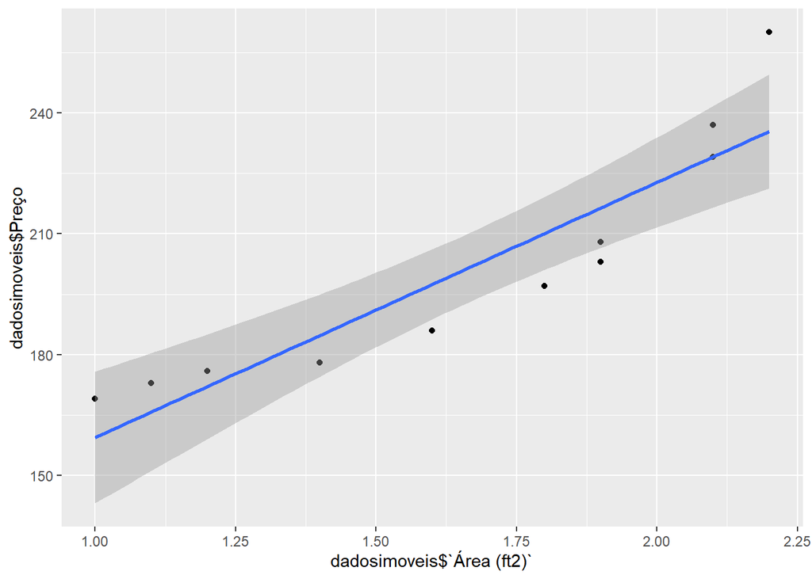

```r
ggplot(data=dadosimoveis,aes(y=dadosimoveis$Preço,x=dadosimoveis$`Área (ft2)`))+geom_point()+geom_smooth(method="lm")
```

Pela análise do grafico de pontos, percebe-se um padrão que o modelo não capturou, ou seja uma distribuição de residuos que não é normalmente distribuida.

Modelo Quadrático

```r
poliregres2 <- lm(formula = dadosimoveis$Preço ~ dadosimoveis$`Área (ft2)` + I(dadosimoveis$`Área (ft2)`^2))
print(poliregres2)
```

```
##
## Call:
## lm(formula = dadosimoveis$Preço ~ dadosimoveis$`Área (ft2)` +
##     I(dadosimoveis$`Área (ft2)`^2))
##
## Coefficients:
##                    (Intercept)       dadosimoveis$`Área (ft2)`
##                         294.97                         -203.38
## I(dadosimoveis$`Área (ft2)`^2)
##                          83.41
```

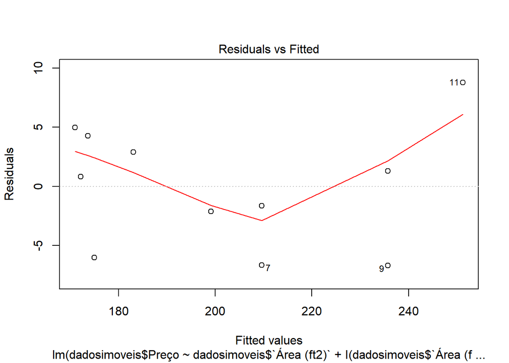

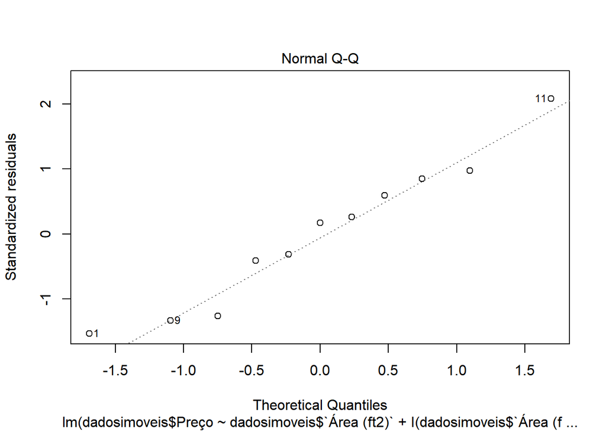

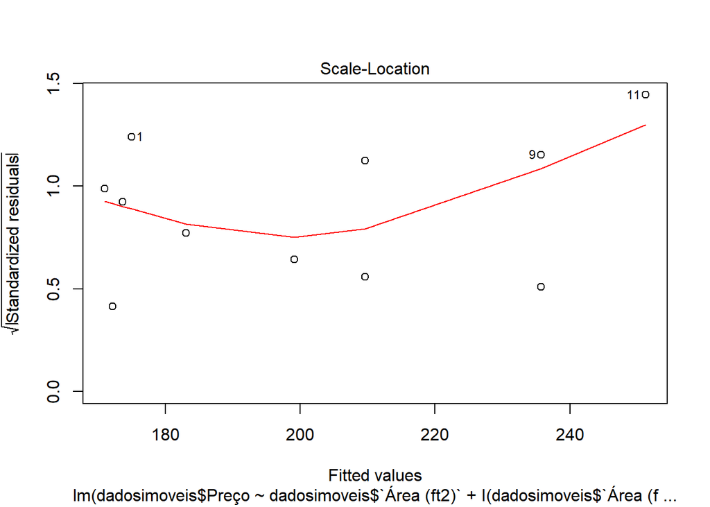

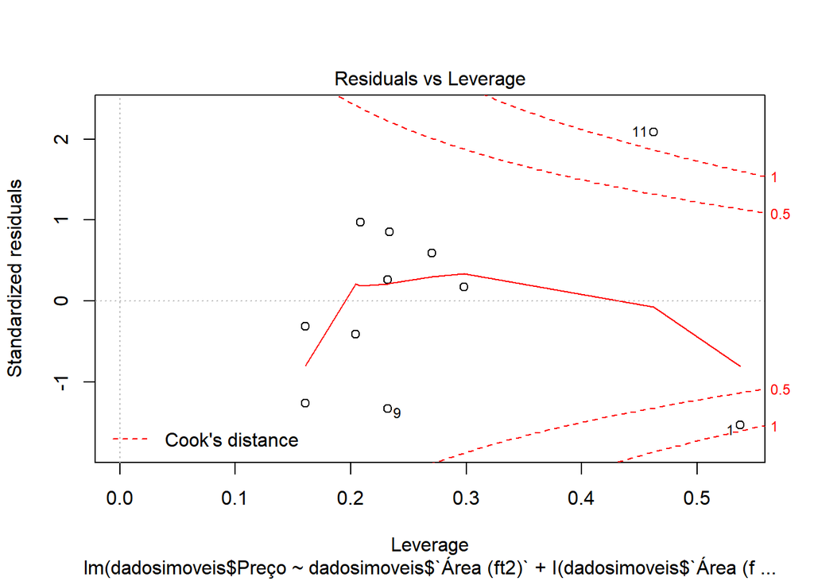

```r
plot(poliregres2)
```

```r
summary(poliregres2)
```

```
##
## Call:
## lm(formula = dadosimoveis$Preço ~ dadosimoveis$`Área (ft2)` +
##     I(dadosimoveis$`Área (ft2)`^2))
##
## Residuals:
##     Min      1Q  Median      3Q     Max
## -6.6928 -4.0591  0.8263  3.6021  8.7806
##
## Coefficients:
##                                Estimate Std. Error t value Pr(>|t|)
## (Intercept)                      294.97      34.24   8.616 2.55e-05 ***
## dadosimoveis$`Área (ft2)`       -203.38      45.09  -4.511 0.001974 **
## I(dadosimoveis$`Área (ft2)`^2)    83.41      14.04   5.941 0.000346 ***
## ---
## Signif. codes:  0 '***' 0.001 '**' 0.01 '*' 0.05 '.' 0.1 ' ' 1
##
## Residual standard error: 5.737 on 8 degrees of freedom
## Multiple R-squared:  0.9701, Adjusted R-squared:  0.9627
## F-statistic: 129.9 on 2 and 8 DF,  p-value: 7.959e-07
```

Apresenta melhor comportamento em relação aos resíduos. Capturando melhor os padrões dos dados.

```r
poliregres3 <- lm(formula = dadosimoveis$Preço ~ dadosimoveis$`Área (ft2)` + I(dadosimoveis$`Área (ft2)`^2) + I(dadosimoveis$`Área (ft2)`^3) )
print(poliregres3)
```

```
##
## Call:
## lm(formula = dadosimoveis$Preço ~ dadosimoveis$`Área (ft2)` +
##     I(dadosimoveis$`Área (ft2)`^2) + I(dadosimoveis$`Área (ft2)`^3))
##
## Coefficients:
##                    (Intercept)       dadosimoveis$`Área (ft2)`
##                         -105.2                           597.7
## I(dadosimoveis$`Área (ft2)`^2)  I(dadosimoveis$`Área (ft2)`^3)
##                         -429.9                           105.9
```

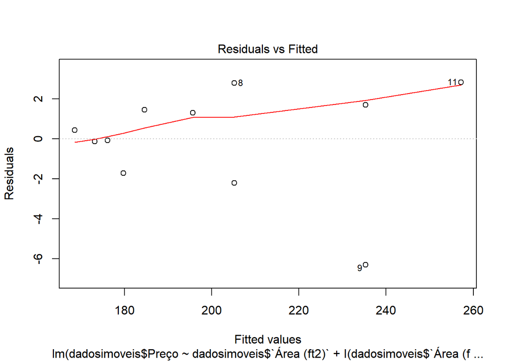

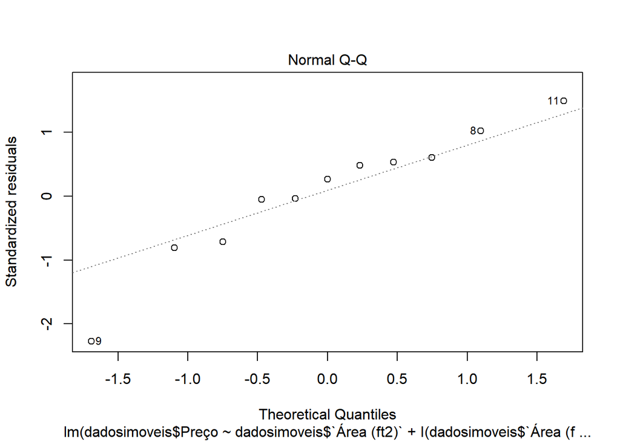

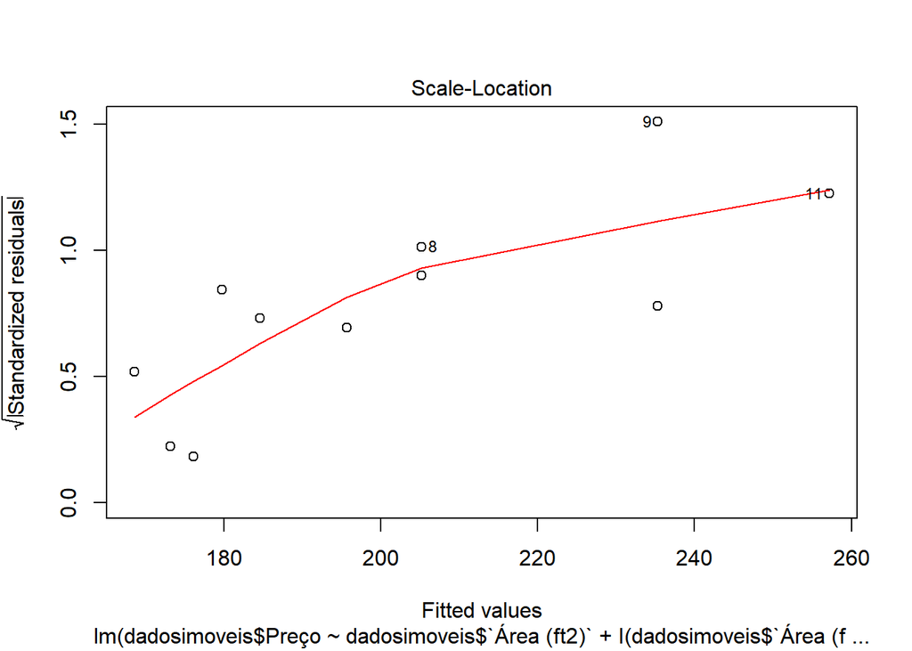

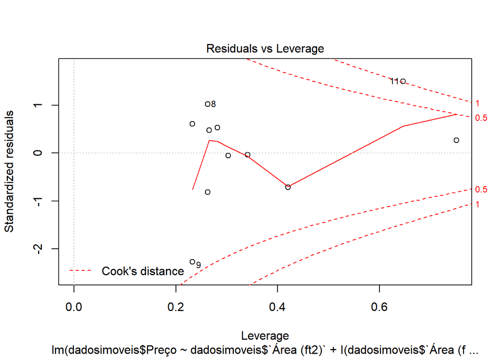

```r
plot(poliregres3)
```

```r
summary(poliregres3)
```

```
##
## Call:
## lm(formula = dadosimoveis$Preço ~ dadosimoveis$`Área (ft2)` +
##     I(dadosimoveis$`Área (ft2)`^2) + I(dadosimoveis$`Área (ft2)`^3))
##
## Residuals:
##     Min      1Q  Median      3Q     Max
## -6.3163 -0.9265  0.4271  1.5610  2.8214
##
## Coefficients:
##                                Estimate Std. Error t value Pr(>|t|)
## (Intercept)                     -105.16      93.22  -1.128  0.29643
## dadosimoveis$`Área (ft2)`        597.68     184.43   3.241  0.01424 *
## I(dadosimoveis$`Área (ft2)`^2)  -429.89     117.35  -3.663  0.00803 **
## I(dadosimoveis$`Área (ft2)`^3)   105.95      24.17   4.384  0.00322 **
## ---
## Signif. codes:  0 '***' 0.001 '**' 0.01 '*' 0.05 '.' 0.1 ' ' 1
##
## Residual standard error: 3.169 on 7 degrees of freedom
## Multiple R-squared:  0.992,  Adjusted R-squared:  0.9886
## F-statistic: 290.2 on 3 and 7 DF,  p-value: 1.051e-07
```

Modelo Superajustado r² adjusted = 0.989, perde-se generalidade.

Portanto o melhor modelo seria a regressao polinomial quadratica, pois explica bem os dados e não é superajustado.